# Solar Battery Savings Model: Documentation and Results

Ibaale Eric

25 October 2026

# Summary of results

I built a model in R that works through Naomi’s 2020 electricity data one hour at a time, first with her solar panels alone and then with a 12.5 kWh battery added, and then projects the saving over the battery’s 20 years. This document sets out what the model does, the checks I ran on the data and on my own calculations, the assumptions I made and the results.

Over 2020 the battery would have met an extra 3,508.0 kWh of Naomi’s usage, which would otherwise have been bought from the provider. At the 1 January 2022 price of $0.17 per kWh that is a saving of $596.36 for the year. Discounted at 6%, the 20 years of savings were worth $9,446 under scenario 1 (prices rising 4% a year) and $10,759 under scenario 2 (4% rising by a further 0.25% each year). Against the $7,000 cost, that gave an NPV of $2,446 and an IRR of 9.45% for scenario 1, and an NPV of $3,759 and an IRR of 10.74% for scenario 2. In both scenarios the NPV was positive and the IRR was above 6%, so on these figures the battery paid for itself within its 20 years.

# 1. Purpose of the model

Naomi has solar panels on her roof. The power they make is used in the house as it is generated, and anything above what the house is using at that moment is wasted because she is not paid for it. She is thinking about buying a battery for $7,000 that would store the extra and give it back later. It would be installed on 1 January 2022, would hold at most 12.5 kWh and would last 20 years.

The model answers the questions she asked me. How much more of her usage could the panels and battery cover together, compared with the panels alone, and what is that worth in dollars? And, for two possible electricity price paths, what is the NPV (at 6% a year) and the IRR of buying the battery?

I wrote the document so that a senior analyst can follow what was done and approve it, and so that a fellow analyst can check the steps, correct them or reuse the model. Table 1 shows where each part of the brief is dealt with.

Table 1: Where each part of the brief is handled

| Part of the brief | Where in this document | Name in the code |
| --- | --- | --- |
| (i) Data checks, hourly averages graph, outliers, corrections | Section 2 | d, checks_tab, fix_usage, fix_solar |
| (ii) Electricity bought, no battery | Sections 4.2 and 5 | bought_nb |
| (iii) Excess solar | Sections 4.3 and 5 | excess |
| (iv) Battery charge level | Sections 4.4 and 5 | level (run_battery) |
| (v) Electricity bought, with battery | Sections 4.5 and 5 | bought_b |
| (vi) Saving over 2020 | Sections 4.6 and 5 | saving_2020 |
| (vii) Monthly table and chart | Sections 4.7 and 5 | monthly |
| (viii) 20 year projection and NPV | Sections 4.8 and 5 | project(), s1, s2 |
| (ix) IRR | Sections 4.9 and 5 | find_irr() |
| (x) Code and documentation | This file | Solar_Battery_Model.Rmd |

The Rmd file reads the Excel file by name, so the Excel file has to be in the same folder as the Rmd file. No file paths on my computer are written into the code. When the file is knitted it also writes the full hourly results to a csv file called hourly_model_results.csv in that folder.

# 2. Data

## 2.1 What I was given

I was given one Excel workbook with two sheets (Raw Data and Scoring). The sheet “Raw Data” holds hourly figures for 2020 in four columns: the hour of the day (0 is midnight to 1 am, 23 is 11 pm to midnight), the date and hour the reading starts, the electricity generated by the solar panels in kWh, and the electricity used in the house in kWh. The brief says 29 February was left out and that I could ignore it, so the year is 365 days. The second sheet, “Scoring”, was empty.

The column names were not in the first row of the sheet. They sat underneath a short note, so I found the header row by looking for the word “Hour” rather than counting rows. The date and hour are stored as one Excel serial number, so I worked out the calendar date and the hour from it and compared the hour with the Hour column.

## 2.2 Checks and results

I ran the checks in Table 2 on the raw data before changing anything.

Table 2: Checks on the raw data and what I found

| Check | Result |
| --- | --- |
| Data rows read from the sheet | 8,760 |
| Rows expected (365 days x 24 hours) | 8,760 |
| Different dates in the file | 365 |
| Rows dated 29 February | 0 |
| Days that did not have exactly 24 rows | 0 |
| Places where the hourly sequence jumped | 1 |
| Rows where the Hour column disagreed with the time stamp | 0 |
| Missing solar values | 0 |
| Missing usage values | 0 |
| Duplicated time stamps | 0 |
| Negative solar values | 0 |
| Negative usage values | 5 |
| Usage above 1,000 kWh in one hour | 1 |
| Daylight hours (9 am to 4 pm) with solar and usage both zero | 4 |
| Usage above 20 kWh in one hour (flagged, kept) | 181 |
| Non-zero solar between 10 pm and 4 am | 537 |
| Usage values with more than 3 decimal places | 2,260 |

I counted 8,760 data rows against 8,760 expected for 365 days of 24 hours. I found 0 missing values and 0 duplicated time stamps, and 0 rows where the Hour column and the time stamp disagreed. The brief says 29 February was left out, which should appear as one jump in the hourly sequence, and Table 2 shows 1 jump(s). Where a duplicated time stamp was found I kept the first row and dropped the rest.

The problems were in the values themselves. There were 5 negative usage readings, which cannot be right because a house cannot use less than nothing. The largest usage reading in the raw file was 46,000.0 kWh, against a typical hour of 0.62 kWh. There were 4 daylight hours in which solar and usage were both exactly zero, which looked like the meter not recording. I also saw 537 small solar readings in the dark hours, the largest being 13.050 kWh. Finally, 2,260 usage values carried long decimals while the rest had three, and some solar values showed floating point noise such as 0.009000000000000001. That is only how the numbers were stored, so I did nothing about it.

## 2.3 Outliers I looked into

Figure 1 is the graph the brief asks for: the average solar generation and the average usage for each hour of the day, using the raw data. I drew it before cleaning so that it would show what the problems did to the averages.

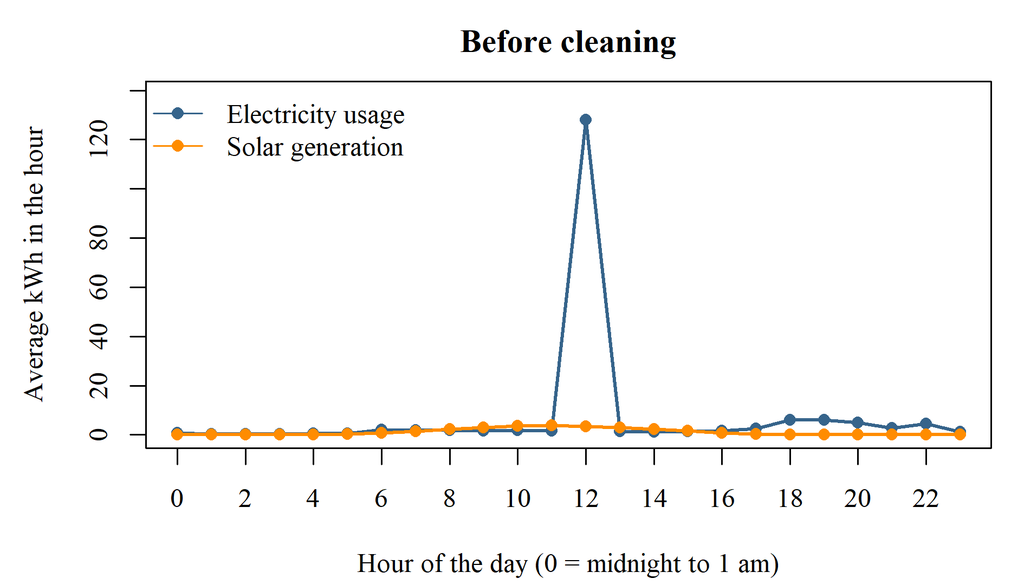

Figure 1: Average solar generation and electricity usage by hour of the day, raw data

The usage line in Figure 1 is pulled out of shape at hour 12, where the average was 128.00 kWh. After cleaning it was 1.97 kWh. I looked at the individual readings to see what caused that, and Figure 2 shows every hourly usage reading in the file.

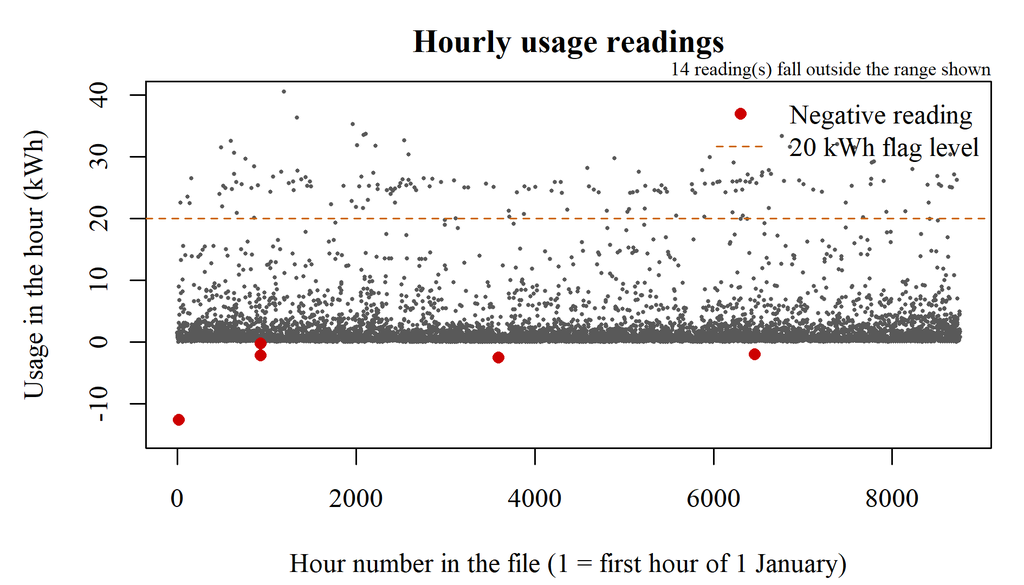

Figure 2: Every hourly usage reading, with the vertical axis cut at 40 kWh. Red points are negative readings; the dashed line is the 20 kWh flag level

I treated the readings as follows.

**Negative usage and usage above 1,000 kWh.** I treated these as errors. A negative usage is not possible, and the large reading (46,000 kWh in one hour at its largest) is far beyond anything a house could use in an hour. I could not tell what the true values were. A sign flip was possible for the negatives, but I had no evidence for it, so I did not use it.

**Both zero in daylight.** At hours 9 to 15 solar is normally well above zero, and a usage of exactly zero is very unusual. When both were zero together I took it as the meter dropping out and treated both values as missing. I only applied this rule between 9 am and 4 pm, because both can be close to zero at night without anything being wrong.

**Usage above 20 kWh.** There were 181 of these, with the highest at 61.1 kWh. I thought about removing them, but I kept them as real usage. A house can reach that level in an hour when an oven, heating and a water heater run together, and nothing in the data proved they were wrong. Big readings are also common in the evening: 156 of the 1,095 readings between 6 pm and 9 pm were above 12 kWh, so the 20s looked like the top of the same pattern. 43 of the spikes fell between 9 am and 1 pm, which was less expected, but the readings were not impossible. Replacing real usage would also have understated what the battery could save, and I show by how much in Section 6.

## 2.4 Corrections

I replaced each bad value with the median for the same hour of the day, worked out from the rows that were not flagged. I chose the hourly median because usage depends heavily on the time of day, and a median is not pulled around by the large readings. For negative usage and for usage above 1,000 kWh I replaced only usage. For the daylight dropouts I replaced both solar and usage. I made 10 row replacements in total. Table 3 shows the first 15.

Table 3: Rows I corrected (first 15), before and after, in kWh

| Date | Hour | Problem | Usage before | Usage after | Solar before | Solar after |
| --- | --- | --- | --- | --- | --- | --- |
| 01 Jan | 10 | Solar and usage both zero in daylight | 0.000 | 0.453 | 0.000 | 2.628 |
| 01 Jan | 11 | Solar and usage both zero in daylight | 0.000 | 0.399 | 0.000 | 2.844 |
| 01 Jan | 17 | Negative usage | -12.624 | 1.104 | 0.006 | 0.006 |
| 12 Jan | 12 | Usage above 1,000 kWh | 46,000.000 | 0.481 | 5.214 | 5.214 |
| 30 Jan | 11 | Solar and usage both zero in daylight | 0.000 | 0.399 | 0.000 | 2.844 |
| 08 Feb | 21 | Negative usage | -2.133 | 1.524 | 0.006 | 0.006 |
| 08 Feb | 23 | Negative usage | -0.218 | 0.908 | 0.000 | 0.000 |
| 30 May | 17 | Negative usage | -2.514 | 1.104 | 1.185 | 1.185 |
| 27 Sep | 8 | Negative usage | -1.977 | 0.649 | 0.717 | 0.717 |
| 30 Dec | 9 | Solar and usage both zero in daylight | 0.000 | 0.492 | 0.000 | 2.080 |

The corrections changed total usage from 64,059.3 kWh to 18,086.3 kWh and total solar from 9,782.7 kWh to 9,793.1 kWh. Figure 3 repeats Figure 1 using the corrected data. The line is now smooth. Usage peaks at hour 18 and solar peaks at hour 11, which is what I expected for a house with panels on the roof.

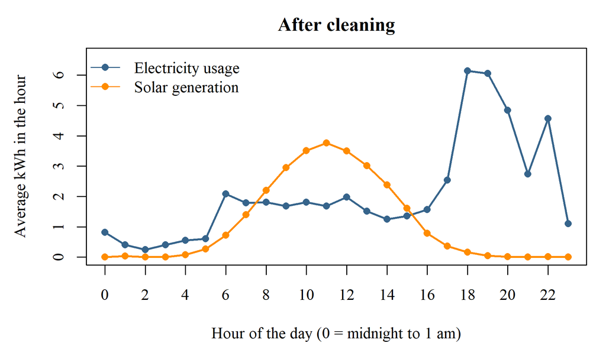

Figure 3: Average solar generation and electricity usage by hour of the day, after corrections

All later results use the corrected data. Appendix A lists the hourly averages behind Figures 1 and 3.

# 3. Assumptions

These are the assumptions I made, in addition to the figures given in the brief.

1. The 2020 data was a typical year. I repeated it for every year from 2022 to 2041, so the battery saves the same number of kWh in each year and only the price changes.
2. I worked in whole hours. Within an hour, usage was met from solar first, then from the battery, then from the provider, and excess solar went into the battery after the hour’s usage was covered.
3. The battery started empty at 1 January 2020 00:00, as the brief says. In the projection I did not carry any charge over from one year to the next.
4. The battery had no losses when charging or discharging, no limit on how fast it could charge or discharge, and no loss of capacity over 20 years. The only limits were 0 and 12.5 kWh.
5. Solar generated when the battery was full was lost. Naomi gets no payment for it, as the brief says.
6. The 2022 price of $0.17 per kWh applied for the whole of 2022 and prices changed each 1 January from 2023. I valued the 2020 saving at 2022 prices, with no discounting, as the brief asks.
7. In scenario 1 the price rose 4% each year. In scenario 2 it rose 4.00% on 1 January 2023, 4.25% in 2024, 4.50% in 2025 and so on, adding 0.25 percentage points each year.
8. The battery was paid for on 1 January 2022. Each year’s saving was received at the end of that year, and I discounted at 6% a year, constant for the 20 years. I ignored tax, maintenance and any cost of replacing parts.
9. For the data, I assumed the replacement values described in Section 2.4 were close enough to the true values, and that the readings above 20 kWh were real usage.

# 4. Methodology

## 4.1 Preparing the data

I read the sheet, found the header row, converted the four columns to numbers, worked out the date and hour of each row, and ran the checks in Section 2. I then corrected the bad values as described in Section 2.4. Everything after this point uses the corrected solar and usage columns.

## 4.2 Electricity bought with no battery (part ii)

For each hour I took usage less solar generation and set any negative answer to zero. If solar is above usage nothing needs to be bought, and the excess is dealt with in the next step.

## 4.3 Excess solar (part iii)

For each hour I took solar generation less usage and set any negative answer to zero. Because of this and the step above, an hour can have excess solar or electricity to buy but not both.

## 4.4 Battery charge level (part iv)

I went through the hours in time order. The level before the first hour was zero. In each hour:

- the battery took in the smaller of the excess solar and the room left (12.5 kWh less the current level). Anything that did not fit was counted as lost;
- the battery gave out the smaller of the electricity that would have had to be bought and the current level;
- the new level was the old level plus what went in, less what came out.

The level at the end of each hour is the charge level reported in the model. A simple loop does this in the code.

## 4.5 Electricity bought with the battery (part v)

For each hour this was the electricity that would have been bought with no battery, less what the battery gave out in that hour. It cannot go below zero because the battery never gives out more than would have been bought.

## 4.6 Saving over 2020 (part vi)

I added up the difference between the two bought columns over the year to get the extra kWh met by the battery. I multiplied that by $0.17 to get the saving in dollars, with no discounting.

## 4.7 Monthly table and chart (part vii)

I added up solar generation, usage, electricity bought with no battery and electricity bought with the battery for each calendar month. The results are in Table 5 and Figure 4.

## 4.8 Projection and NPV (part viii)

The saving in each year was the extra kWh from Section 4.6 multiplied by that year’s price. For scenario 1 the price in each year was the previous year’s price times 1.04. For scenario 2 it was the previous year’s price times 1.04, then 1.0425, 1.045 and so on. I discounted each year’s saving by (1 + 0.06) raised to the number of years since 1 January 2022 (1 for 2022, 2 for 2023, and so on) and added them up. I report this present value and also the NPV, which is the present value less the $7,000 cost.

## 4.9 IRR (part ix)

I found the discount rate at which the present value of the 20 years of savings equals the $7,000 cost, using a root finder (uniroot in R) searching between -50% and 500%. I did this separately for each scenario.

# 5. Results

## 5.1 Electricity bought, saved and lost in 2020

Table 4: Annual totals for 2020 (kWh)

| Item | kWh |
| --- | --- |
| Solar generation | 9,793.1 |
| Electricity usage | 18,086.3 |
| Bought from the provider, no battery | 15,628.8 |
| Bought from the provider, with battery | 12,120.8 |
| Extra electricity met by the battery (the difference) | 3,508.0 |
| Excess solar with no battery | 7,335.6 |
| Excess solar that went into the battery | 3,508.0 |
| Excess solar lost because the battery was full | 3,827.7 |

The battery met an extra 3,508.0 kWh, or 22.4% of what Naomi would have bought without it. At $0.17 per kWh the saving over 2020 was $596.36.

## 5.2 Monthly figures

Table 5: Monthly totals for 2020 (kWh)

| Month | Solar | Usage | Bought, no battery | Bought, with battery | Saved by battery |
| --- | --- | --- | --- | --- | --- |
| Jan | 274.6 | 1,720.6 | 1,600.7 | 1,459.7 | 141.0 |
| Feb | 449.6 | 1,562.4 | 1,395.2 | 1,193.3 | 201.9 |
| Mar | 602.5 | 1,797.9 | 1,619.0 | 1,384.8 | 234.2 |
| Apr | 915.1 | 1,726.4 | 1,460.5 | 1,144.1 | 316.4 |
| May | 1,641.4 | 947.4 | 717.3 | 339.9 | 377.4 |
| Jun | 1,408.3 | 1,159.0 | 844.8 | 447.6 | 397.2 |
| Jul | 1,371.5 | 1,197.0 | 907.4 | 470.6 | 436.8 |
| Aug | 1,158.6 | 1,491.5 | 1,217.9 | 792.6 | 425.3 |
| Sep | 835.7 | 1,623.3 | 1,398.8 | 1,040.8 | 358.1 |
| Oct | 546.1 | 1,420.7 | 1,260.3 | 967.4 | 293.0 |
| Nov | 381.7 | 1,479.0 | 1,354.2 | 1,125.4 | 228.8 |
| Dec | 208.0 | 1,961.1 | 1,852.5 | 1,754.5 | 98.0 |
| Year | 9,793.1 | 18,086.3 | 15,628.8 | 12,120.8 | 3,508.0 |

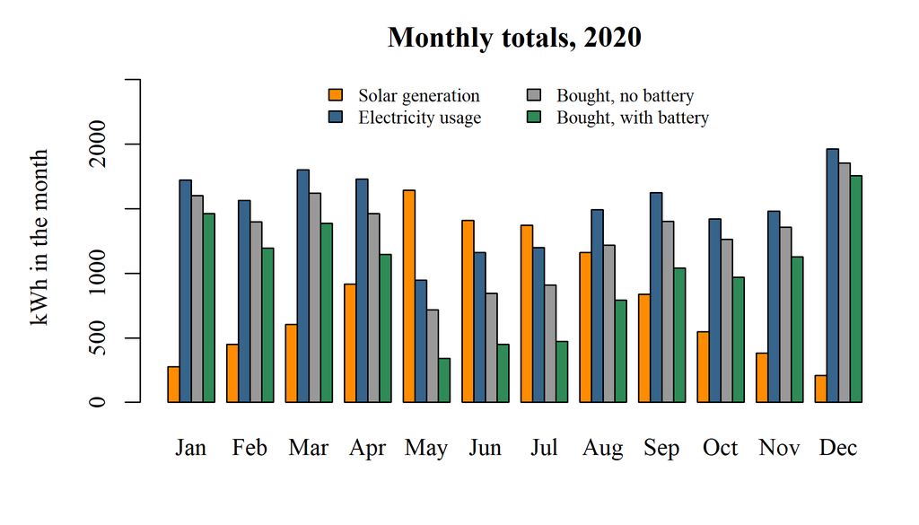

Figure 4: Monthly solar generation, usage and electricity bought, with and without the battery (kWh)

## 5.3 How the battery behaved

Figure 5 shows one week (13 to 19 January) to give a picture of what the battery did hour by hour. It charges while there is solar above usage and runs down when usage is higher than solar.

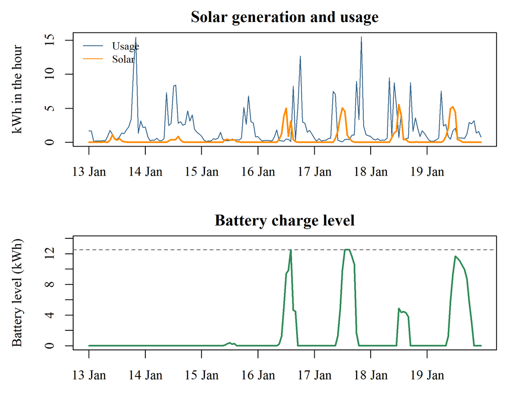

Figure 5: Solar, usage and battery level, 13 to 19 January 2020

Over the year the battery was full in 1,095 hours and empty in 4,778 of the 8,760 hours. It captured 47.8% of the excess solar, and 3,827.7 kWh was lost because it was full.

## 5.4 Projection, NPV and IRR

Figure 6 shows the two price paths and Table 6 shows the 20 years of savings for each.

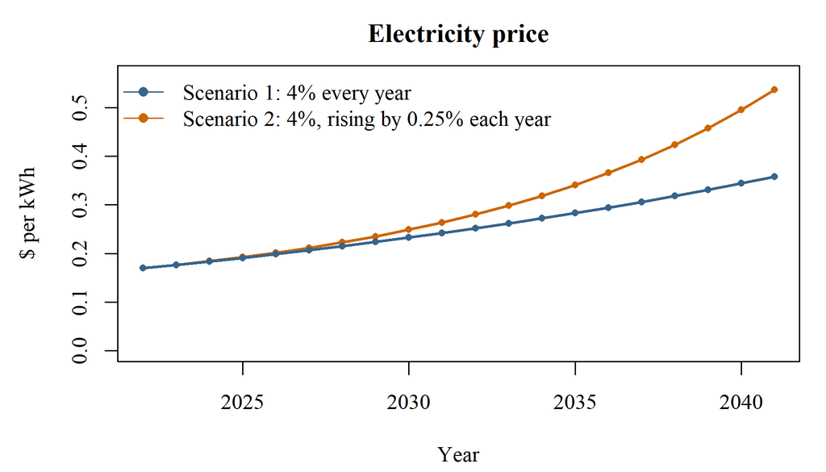

Figure 6: Electricity price per kWh, 2022 to 2041, under the two scenarios

Table 6: Projected savings. Price in $ per kWh, saving and discounted saving in $. S1 = scenario 1, S2 = scenario 2

| Year | S1 price | S1 saving | S1 discounted | S2 price | S2 saving | S2 discounted |
| --- | --- | --- | --- | --- | --- | --- |
| 2022 | 0.1700 | 596.36 | 562.60 | 0.1700 | 596.36 | 562.60 |
| 2023 | 0.1768 | 620.21 | 551.99 | 0.1768 | 620.21 | 551.99 |
| 2024 | 0.1839 | 645.02 | 541.57 | 0.1843 | 646.57 | 542.87 |
| 2025 | 0.1912 | 670.82 | 531.35 | 0.1926 | 675.66 | 535.19 |
| 2026 | 0.1989 | 697.65 | 521.33 | 0.2018 | 707.76 | 528.88 |
| 2027 | 0.2068 | 725.56 | 511.49 | 0.2118 | 743.15 | 523.89 |
| 2028 | 0.2151 | 754.58 | 501.84 | 0.2230 | 782.16 | 520.18 |
| 2029 | 0.2237 | 784.76 | 492.37 | 0.2352 | 825.18 | 517.73 |
| 2030 | 0.2327 | 816.15 | 483.08 | 0.2488 | 872.63 | 516.51 |
| 2031 | 0.2420 | 848.80 | 473.97 | 0.2637 | 924.99 | 516.51 |
| 2032 | 0.2516 | 882.75 | 465.02 | 0.2802 | 982.80 | 517.73 |
| 2033 | 0.2617 | 918.06 | 456.25 | 0.2984 | 1,046.68 | 520.17 |
| 2034 | 0.2722 | 954.79 | 447.64 | 0.3185 | 1,117.33 | 523.85 |
| 2035 | 0.2831 | 992.98 | 439.19 | 0.3408 | 1,195.54 | 528.79 |
| 2036 | 0.2944 | 1,032.70 | 430.91 | 0.3655 | 1,282.22 | 535.03 |
| 2037 | 0.3062 | 1,074.00 | 422.78 | 0.3929 | 1,378.39 | 542.60 |
| 2038 | 0.3184 | 1,116.96 | 414.80 | 0.4234 | 1,485.21 | 551.56 |
| 2039 | 0.3311 | 1,161.64 | 406.97 | 0.4573 | 1,604.03 | 561.96 |
| 2040 | 0.3444 | 1,208.11 | 399.30 | 0.4950 | 1,736.36 | 573.89 |
| 2041 | 0.3582 | 1,256.43 | 391.76 | 0.5370 | 1,883.95 | 587.43 |
| Total |  | 17,758.34 | 9,446.21 |  | 21,107.19 | 10,759.33 |

Table 7: NPV and IRR of the battery for the two scenarios

| Measure | Scenario 1 | Scenario 2 |
| --- | --- | --- |
| Total savings over 20 years, not discounted ($) | 17,758 | 21,107 |
| Present value of savings at 6% ($) | 9,446 | 10,759 |
| Battery cost ($) | 7,000 | 7,000 |
| NPV after the battery cost ($) | 2,446 | 3,759 |
| IRR | 9.45% | 10.74% |
| Year the discounted savings pass the cost | 2036 | 2035 |

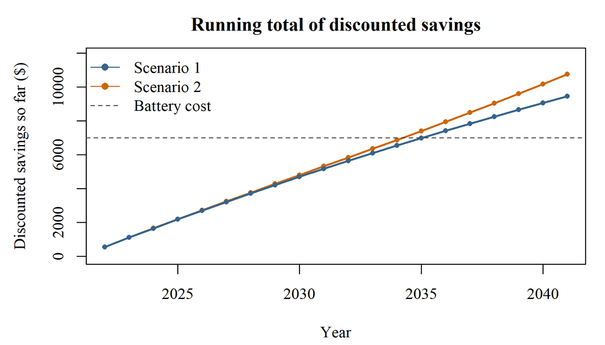

Figure 7: Running total of discounted savings against the cost of the battery

Under scenario 1 the present value of the savings was $9,446, so the NPV was $2,446 and the IRR was 9.45%. Under scenario 2 the present value was $10,759, the NPV was $3,759 and the IRR was 10.74%. In both scenarios the NPV was positive and the IRR was above 6%, so on these figures the battery paid for itself within its 20 years.

To break even at 6%, the battery would have had to save about $442 in the first year under scenario 1 (2,600 kWh) and about $388 under scenario 2 (2,282 kWh). The model gave $596 (3,508 kWh).

# 6. Further checks

## 6.1 Self-checks in the model

I built checks into the code that run every time the file is knitted. Table 8 lists them. All of them passed. One of them is a second, separate calculation of the battery level that uses a different formula from the loop in the main model, and the two agreed.

Table 8: Self-checks built into the model

|  | Check | Result |
| --- | --- | --- |
| No negative values in the bought, excess and battery columns | No negative values in the bought, excess and battery columns | Passed |
| Battery level always between 0 and 12.5 kWh | Battery level always between 0 and 12.5 kWh | Passed |
| Battery started empty (first level equals first charge less first discharge) | Battery started empty (first level equals first charge less first discharge) | Passed |
| Each hour: usage = solar used + battery + bought (with battery) | Each hour: usage = solar used + battery + bought (with battery) | Passed |
| Each hour: usage = solar used + bought (no battery) | Each hour: usage = solar used + bought (no battery) | Passed |
| No hour with both excess solar and electricity bought | No hour with both excess solar and electricity bought | Passed |
| Excess solar = solar charged + solar lost, every hour | Excess solar = solar charged + solar lost, every hour | Passed |
| Total charged = total discharged + final battery level | Total charged = total discharged + final battery level | Passed |
| Never more bought with the battery than without | Never more bought with the battery than without | Passed |
| Battery never gave out more than it held | Battery never gave out more than it held | Passed |
| Electricity saved by the battery is no more than the excess solar | Electricity saved by the battery is no more than the excess solar | Passed |
| Battery level matches the second, independent calculation | Battery level matches the second, independent calculation | Passed |
| Monthly totals add up to the annual totals | Monthly totals add up to the annual totals | Passed |
| Discounting 20 years of 1 at 6% matches the annuity formula | Discounting 20 years of 1 at 6% matches the annuity formula | Passed |
| Price paths match a hand calculation (2023 in scenario 1, 2025 in scenario 2) | Price paths match a hand calculation (2023 in scenario 1, 2025 in scenario 2) | Passed |
| Present value at the IRR equals the battery cost (both scenarios) | Present value at the IRR equals the battery cost (both scenarios) | Passed |

## 6.2 Reasonableness checks

I also looked at whether the numbers made sense.

## 6.3 Sensitivity to two choices I made

I re-ran the model with two changes to see how much my choices mattered. The first replaced the readings above 20 kWh with the hourly median as well. The second assumed the savings arrive in the middle of each year rather than at the end.

Table 9: Sensitivity of the results to two choices

| Case | Total usage (kWh) | Extra kWh from battery | Saving in 2020 ($) | NPV S1 ($) | NPV S2 ($) |
| --- | --- | --- | --- | --- | --- |
| What I used | 18,086 | 3,508.0 | 596.36 | 2,446 | 3,759 |
| Readings above 20 kWh replaced | 13,330 | 3,390.6 | 576.40 | 2,130 | 3,399 |
| Savings received mid-year | 18,086 | 3,508.0 | 596.36 | 2,725 | 4,077 |

Replacing the large readings changed total usage from 18,086 kWh to 13,330 kWh and the extra kWh from the battery from 3,508.0 to 3,390.6. Moving the receipt of savings to mid-year raised the NPV by about $279 in scenario 1 and $318 in scenario 2.

# 7. Evaluation of the method and the results

I want to be clear about where the results are weaker.

1. **One year of data stands in for twenty.** I assumed every year from 2022 to 2041 looks like 2020. Naomi’s usage could change (an electric car or a new appliance, for example), and solar output changes with the weather. Because the NPV rests on this repetition, a different mix of sunny and cloudy years would move it.
2. **The battery was treated as perfect.** Real batteries lose some energy when charging and discharging, they have limits on how quickly they can charge and discharge, and they lose capacity with age. All of these would reduce the saving, so my figures are on the generous side.
3. **Hourly data hides what happens within an hour.** Excess solar and usage can both happen inside the same hour, and I netted them. The hourly view could slightly overstate or understate the energy the battery would really have stored.
4. **My corrections were estimates.** The replacement values were medians, not the true readings. There were only 10 of them out of 8,760 hours, and Table 3 shows the replacements were ordinary values, so I think the effect on the annual totals is small. The larger judgement was keeping the readings above 20 kWh. Table 9 shows that choice changes the size of the saving, so it is the assumption I would most want the senior analyst to look at.
5. **The price paths are given, not forecast.** I used the two scenarios in the brief. The IRR and NPV are sensitive to price inflation because the savings are paid over a long period, as Figure 7 shows.
6. **The discounting convention matters a little.** Savings at the end of the year is a cautious choice, and Table 9 shows the mid-year alternative.
7. **Things I left out.** Maintenance, the cost of replacing equipment during the 20 years, tax, and any change in the panels’ output. None of them was in the brief.
8. **The 12.5 kWh limit.** The battery was full in 1,095 of the 8,760 hours. So the size limit did bind for part of the year, and a larger battery might have saved more.

# Appendix A: Average by hour of the day

Table 10: Average kWh per hour, before and after corrections

| Hour | Solar, raw | Solar, corrected | Usage, raw | Usage, corrected |
| --- | --- | --- | --- | --- |
| 0 | 0.000 | 0.000 | 0.816 | 0.816 |
| 1 | 0.036 | 0.036 | 0.402 | 0.402 |
| 2 | 0.000 | 0.000 | 0.251 | 0.251 |
| 3 | 0.000 | 0.000 | 0.408 | 0.408 |
| 4 | 0.079 | 0.079 | 0.552 | 0.552 |
| 5 | 0.271 | 0.271 | 0.611 | 0.611 |
| 6 | 0.723 | 0.723 | 2.084 | 2.084 |
| 7 | 1.395 | 1.395 | 1.788 | 1.788 |
| 8 | 2.206 | 2.206 | 1.799 | 1.806 |
| 9 | 2.942 | 2.947 | 1.682 | 1.683 |
| 10 | 3.504 | 3.511 | 1.807 | 1.808 |
| 11 | 3.752 | 3.767 | 1.685 | 1.688 |
| 12 | 3.496 | 3.496 | 128.000 | 1.974 |
| 13 | 3.013 | 3.013 | 1.513 | 1.513 |
| 14 | 2.381 | 2.381 | 1.249 | 1.249 |
| 15 | 1.609 | 1.609 | 1.356 | 1.356 |
| 16 | 0.791 | 0.791 | 1.566 | 1.566 |
| 17 | 0.367 | 0.367 | 2.495 | 2.543 |
| 18 | 0.161 | 0.161 | 6.140 | 6.140 |
| 19 | 0.047 | 0.047 | 6.056 | 6.056 |
| 20 | 0.013 | 0.013 | 4.844 | 4.844 |
| 21 | 0.009 | 0.009 | 2.733 | 2.743 |
| 22 | 0.010 | 0.010 | 4.570 | 4.570 |
| 23 | 0.000 | 0.000 | 1.098 | 1.101 |